# Conjugate Priors

Nikolai German

21.05.2025

Let $X = (X_1,\dots, X_n)$ be an i.i.d. exponentially distributed random vector with parameter $\lambda$, that is $X_i \sim Exp(\lambda), i = 1,\dots, n$. We are interested in the distribution of the unknown parameter $\lambda$, and assume a gamma distribution for $\lambda$, so that $\lambda \sim Gamma(\alpha, \beta)$ and $X_i|\lambda \sim Exp(\lambda)$. The density of the exponential distribution is given by: $f(x; \lambda) = \lambda e^{− \lambda x}$. For a gamma distributed variable Y, it holds that $f(y; \alpha, \beta) \propto y^{\alpha−1}e^{− \beta y}$ with the expected value given by $\mathbb{E}(Y) = \frac{\alpha}{\beta}$.

(a) Explain the concept of a conjugate prior.

Using Bayes Theorem’ with parameterized densities, we can obtain the following:

$$\begin{equation}
p(\theta | x) = \frac{f(x | \theta) \cdot p(\theta)}{\int f(x | \tilde{\theta}) \cdot p(\tilde{\theta}) d\tilde{\theta}} \label{eq:1}
\end{equation}
\qquad(1)$$

Where:

- $p(\theta)$ is the prior distribution of the paramter $\theta$
- $f(x | \theta)$ is the likelihood of a sample $x$ given $\theta$
- $p(\theta | x)$ is the posterior distribution of $\theta$ given the sample $x$
- We observe two challenges:
  - $p(\theta | x)$ does not neccessarily take the form of an known distribution
  - $\int f(x | \tilde{\theta}) \cdot p(\tilde{\theta}) d\tilde{\theta}$ can be analytically unsolveable
- A way to overcome these challenges is the following:

  Find a pair of likelihood and prior, so the resulting posterior belongs to a tractable distribution.
- The idea of a *conjugate prior* goes even further:

  **A prior is called conjugate to a likelihood, if the posterior distribution is from the same family of distributions as the prior distribution.**
- Such a prior distribution does not need to exist.

(b) Show that the gamma distribution is a conjugate prior for the exponential likelihood by computing the posterior distribution. State the setup and explain your steps.

We want to show the following:

$$p(\lambda | x) \sim Gamma(\alpha^*, \beta^*)$$

We identify the likelihood as:

$$f(x | \lambda) = \prod_{i=1}^n f(x_i | \lambda) = \prod_{i=1}^n \lambda e^{-\lambda x_i}$$

and the prior distribution as:

$$p(\lambda | \alpha, \beta) \propto \lambda^{\alpha - 1} e^{-\beta \lambda}$$

Subsequently using Equation 1, we can obtain:

$$p(\lambda | x) \propto \biggl[ \prod_{i=1}^n f(x_i | \lambda) \biggr] \cdot p(\lambda | \alpha, \beta)$$

Plugging in the likelihood and the priors’ distribution, gives us:

$$\begin{align}
p(\lambda | x)
&\propto \biggl[ \prod_{i=1}^n \lambda e^{-\lambda x_i} \biggr] \cdot \lambda^{\alpha - 1} e^{-\beta \lambda} \nonumber \\
&= \lambda^n e^{-\lambda \cdot n \bar{x}} \lambda^{\alpha - 1} e^{-\beta \lambda} \nonumber \\
&= \lambda^{n + \alpha -1} e^{-\lambda (\beta + n \bar{x})} \label{eq:3}
\end{align}
\qquad(2)$$

We observe, that Equation 2 is the core of a $Gamma(\alpha + n,\beta + n\bar{x})$ distribution.

Therefore we conclude:

$$\begin{equation}
\lambda|x \sim Gamma(\alpha + n,\beta + n\bar{x}) \label{eq:4}
\end{equation}
\qquad(3)$$

(c) Your prior knowledge on $\lambda$ can be captured by $Gamma(2, 3)$. You have now collected a sample $x = (1, 1, 2, 1, 3, 1, 4, 6, 1, 1)$. Specify the updated posterior parameters $\alpha^*$ and $\beta^*$ and compute the posterior mean $\mathbb{E}(\lambda^*)$.

Using Equation 3, $n = 10$ and $n\bar{x} = 21$, we can compute $\alpha^*$ and $\beta^*$ easily:

$$\begin{align}
\alpha^* &= \alpha + n = 12 \\
\beta^* &= \beta + n\bar{x} = 24
\end{align}$$

We know that for a Gamma distributed RV $Y \sim Gamma(\alpha, \beta)$ ist holds that $\mathbb{E}(Y)=\frac{\alpha}{\beta}$.

Therefore we obtain

$$\mathbb{E}(\lambda^*) = \frac{\alpha^*}{\beta^*} = \frac{1}{2}$$

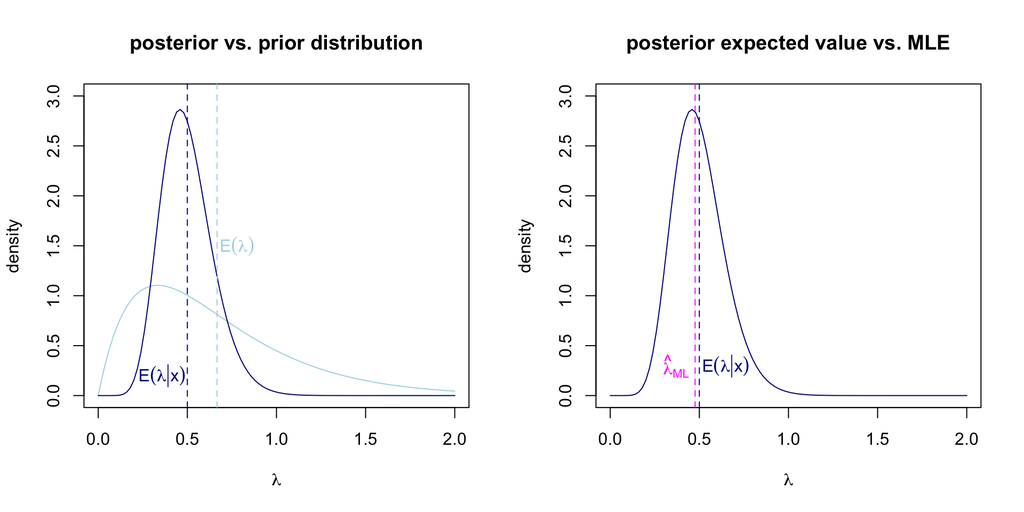

(d) What are the advantages and disadvantages of using conjugate priors? Discuss how these properties affect the choice of prior distribution and the resulting posterior inference.

Advantages

- conjugate priors yield closed-form posteriors
- the posterior can be easily interpreted as the prior with updated parameters
- with growing sample size, the approach yields the same result as the frequentist approach

Disadvantages

- choosing a prior based on mathematical convenience may result in a missspecification
- limited possibilities
- oversimplification of real-world relationsships

Choice of priors and posterior inference

- priors should be chosen carefully, incorporating domain knowledge while maximizing entropy
- if computation is a sparse ressource, conjugated priors could be favorable
- for big n, the choice of prior becomes less important
- posterior inference can be done analytically
- uncertainty quantification through the posterior distribution